# Practical_1_SSR

Soumarya Basak

14/04/2022

```r
#########  Practical 1 ##########
library(readxl)
library(readr)
library(tidyverse)
```

```r
library(dplyr)
library(ggplot2)
library(olsrr)
###### Data set #########
df<- read.csv("C:\\Users\\souma\\Dropbox\\Mstat_CU\\Sem 2\\Regression_analysis_1\\Data Sets\\cigaratte_dataset.csv")
colnames(df)<- c("Index","y_var","x_var")
```

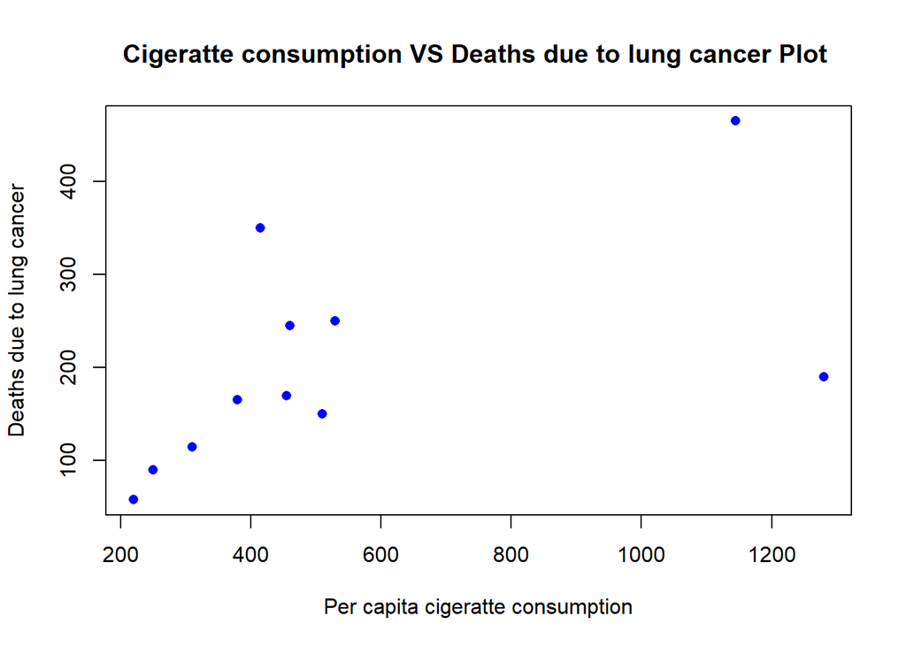

```r
plot(df$x_var,df$y_var,pch=16,col="blue",
     xlab="Per capita cigeratte consumption",ylab = "Deaths due to lung cancer",
     main="Cigeratte consumption VS Deaths due to lung cancer Plot ")
```

```r
###### (a) ########

ssr1<- lm(y_var~x_var,df)
summary(ssr1)
```

```
##
## Call:
## lm(formula = y_var ~ x_var, data = df)
##
## Residuals:
##     Min      1Q  Median      3Q     Max
## -158.90  -52.79  -17.46   52.21  170.36
##
## Coefficients:
##             Estimate Std. Error t value Pr(>|t|)
## (Intercept) 98.42920   59.30799   1.660   0.1314
## x_var        0.19568    0.09343   2.094   0.0657 .
## ---
## Signif. codes:  0 '***' 0.001 '**' 0.01 '*' 0.05 '.' 0.1 ' ' 1
##
## Residual standard error: 102.7 on 9 degrees of freedom
## Multiple R-squared:  0.3277, Adjusted R-squared:  0.253
## F-statistic: 4.387 on 1 and 9 DF,  p-value: 0.06571
```

**For the F test, the p value is more than 0.05, so the parameters the insignificant.**

Both the parameters are not significant

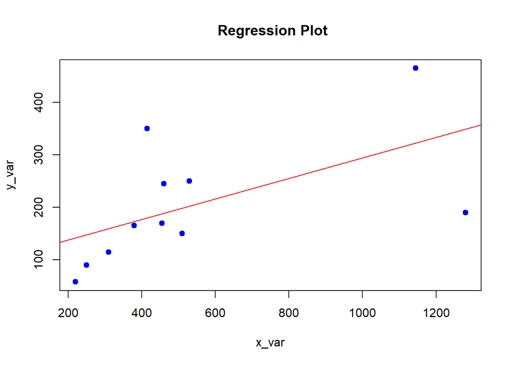

```r
plot(df$x_var,df$y_var,pch=19,col="blue",
     xlab="x_var",ylab = "y_var",
     main=" Regression Plot")
abline(ssr1,col="red")
```

This is due to the influential observation

# The residuals

```r
res<- residuals(ssr1)
cbind("Residuals"=res)
```

```
##      Residuals
## 1   -83.478964
## 2   -44.090230
## 3    -7.787881
## 4  -158.900543
## 5    47.860008
## 6   142.516357
## 7   -57.349386
## 8   -48.226377
## 9   -17.463937
## 10   56.557660
## 11  170.363293
```

## STandardize Residuals

```r
res_std<- rstandard(ssr1)
cbind("Standaredize_Residuals"=res_std)
```

```
##    Standaredize_Residuals
## 1             -0.89544653
## 2             -0.46154959
## 3             -0.08047462
## 4             -2.28633046
## 5              0.48868724
## 6              1.77978693
## 7             -0.60956366
## 8             -0.49261973
## 9             -0.17891785
## 10             0.57921016
## 11             1.75221345
```

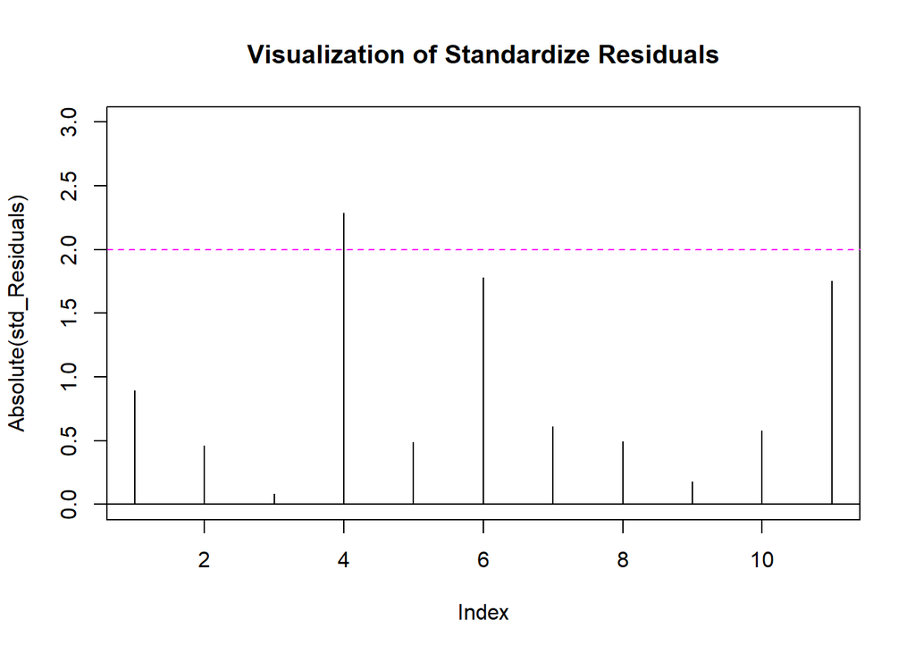

```r
plot(abs(res_std),type='h',
     ylab = "Absolute(std_Residuals)",ylim = c(0,3),
     main="Visualization of Standardize Residuals")
abline(h=0)
abline(h=2,lty=2,col='magenta')
```

## Studentize Residuals

```r
res_stu<-rstudent(ssr1)
cbind("Studentize_Residuals"=res_stu)
```

```
##    Studentize_Residuals
## 1           -0.88455745
## 2           -0.44039638
## 3           -0.07589952
## 4           -3.32934087
## 5            0.46697601
## 6            2.08444722
## 7           -0.58694596
## 8           -0.47083750
## 9           -0.16898616
## 10           0.55655620
## 11           2.03523182
```

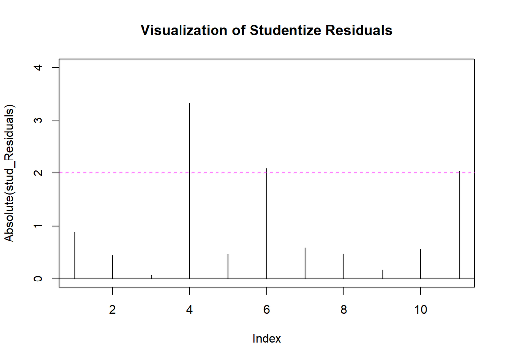

```r
plot(abs(res_stu),type='h',
     ylab = "Absolute(stud_Residuals)",ylim = c(0,4),
     main="Visualization of Studentize Residuals"
     )
abline(h=2,col='magenta',lty=2)
abline(h=0)
```

So studentize residual says that there are three outliers in y_var

#### To find the y outliers

```r
df[which(abs(res_stu)>=2),]
```

|  | Index | y_var | x_var |
| --- | --- | --- | --- |
| 4 | United States | 190 | 1280 |
| 6 | Great Britain | 465 | 1145 |
| 11 | Finland | 350 | 415 |

## Leverage

```r
lev<-hatvalues(ssr1)
cbind("Leverage"=lev)
```

```
##      Leverage
## 1  0.17634086
## 2  0.13518996
## 3  0.11244867
## 4  0.54223194
## 5  0.09101591
## 6  0.39233234
## 7  0.16113488
## 8  0.09172282
## 9  0.09707913
## 10 0.09638538
## 11 0.10411810
```

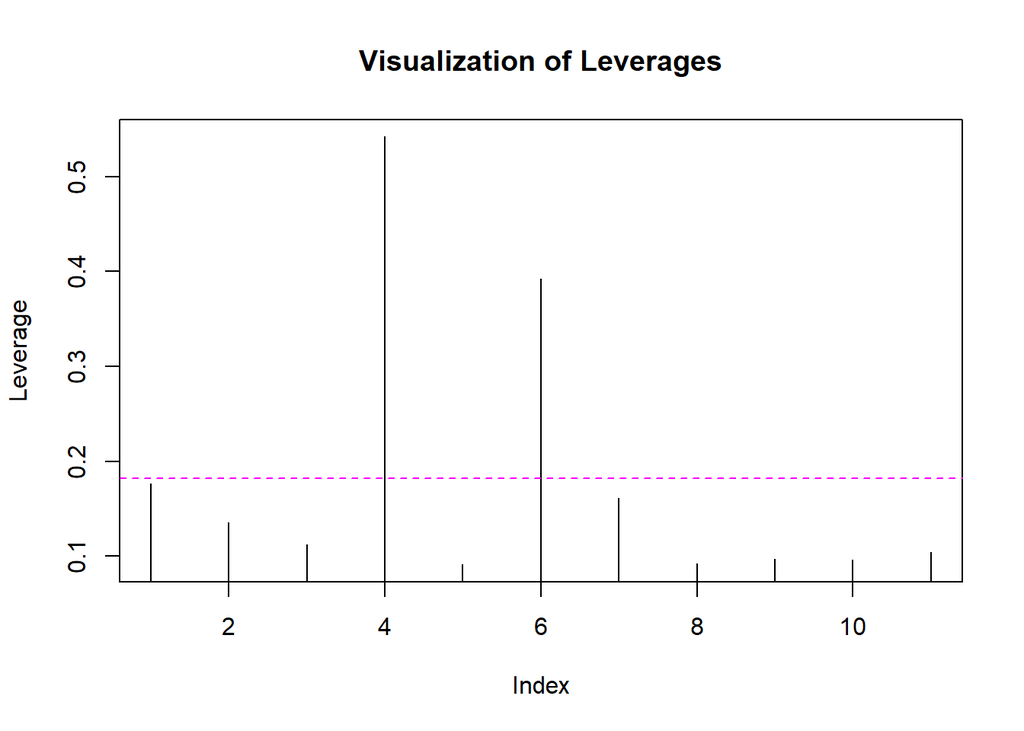

```r
plot(lev,type='h',
     ylab="Leverage", main="Visualization of Leverages"
     )
abline(h=(2/11),col='magenta',lty=2)
```

From the image it is clear that there are two 2 x outlier  
as two values are more than $\frac{2p}{n}=\frac{2}{11}$

#### To Identify the x outliers

```r
# arrange in decreasing order
cbind("Leverage"=lev[order(-lev)])
```

```
##      Leverage
## 4  0.54223194
## 6  0.39233234
## 1  0.17634086
## 7  0.16113488
## 2  0.13518996
## 3  0.11244867
## 11 0.10411810
## 9  0.09707913
## 10 0.09638538
## 8  0.09172282
## 5  0.09101591
```

so the 4th and 6th obsns are x-outliers

# DFBETA

```r
db<-dfbetas(ssr1)
db
```

```
##    (Intercept)        x_var
## 1  -0.39641388  0.284880021
## 2  -0.15955137  0.099653248
## 3  -0.02276883  0.011823905
## 4   2.04443096 -3.305819823
## 5   0.08143844 -0.005062287
## 6  -0.83095128  1.468068127
## 7  -0.24573243  0.169824513
## 8  -0.08980784  0.014092928
## 9  -0.03991472  0.013969157
## 10  0.12913805 -0.043327210
## 11  0.54932238 -0.247128933
```

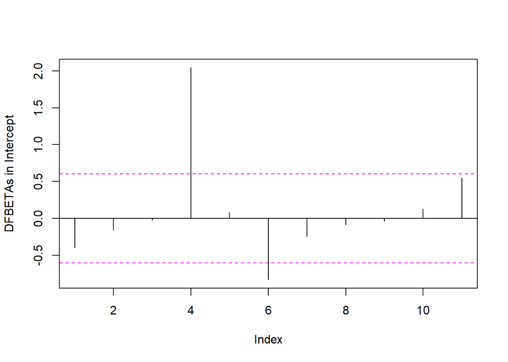

```r
#par(mfrow=c(1,2))
plot(db[,1],type='h',
     ylab = "DFBETAs in Intercept")
abline(h=0)
abline(h=2/(sqrt(11)),lty=2, col="magenta")
abline(h=-2/(sqrt(11)),lty=2,col="magenta")
```

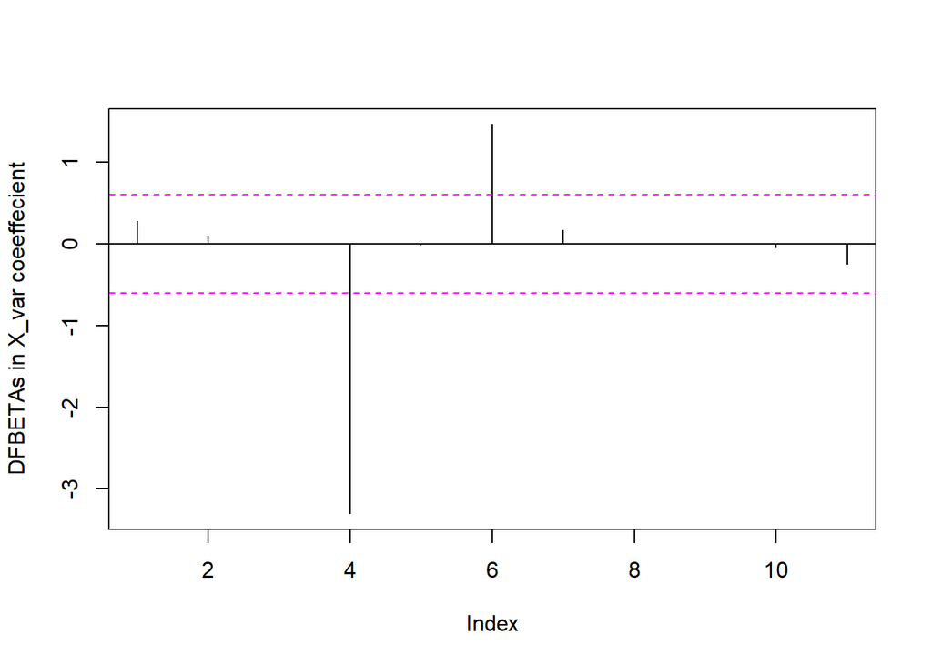

```r
plot(db[,2],type='h',
     ylab = "DFBETAs in X_var coeeffecient")
abline(h=0)
abline(h=2/(sqrt(11)),lty=2,col="magenta")
abline(h=-2/(sqrt(11)),lty=2,col="magenta")
```

so, is clear that there are 2 influencial observation

```r
print(which( abs(db[,1]) >2/(sqrt(11)) ) )
```

```
## 4 6
## 4 6
```

```r
paste(" ")
```

```
## [1] " "
```

```r
which( abs(db[,2]) >2/(sqrt(11)) )
```

```
## 4 6
## 4 6
```

SO, for the 4th and 6th obs the DFBETa is high

# DFFIT

range $=\frac{2}{\sqrt(11)}$

```r
d_fit<-dffits(ssr1)
cbind("DEFIT"=d_fit)
```

```
##          DEFIT
## 1  -0.40928777
## 2  -0.17412279
## 3  -0.02701590
## 4  -3.62349834
## 5   0.14776620
## 6   1.67488461
## 7  -0.25724494
## 8  -0.14962375
## 9  -0.05541014
## 10  0.18177033
## 11  0.69382767
```

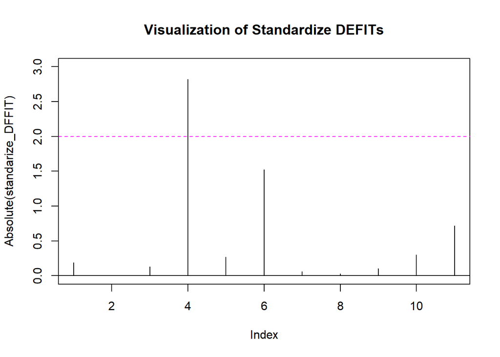

```r
### Standardization of DFFIT

v<- var(d_fit)*( (length(d_fit)-1)/length(d_fit) ) # variance of DFFIT

std_d_fit <- (d_fit - mean(d_fit))/sqrt(v)


plot(abs(std_d_fit),type='h', ylim = c(0,3),
     ylab = "Absolute(standarize_DFFIT)",
     main = "Visualization of Standardize DEFITs")
abline(h=0)
abline(h=2,lty=2,col='magenta')
```

#### To identify the outlier

```r
cbind("DFFIT"=d_fit[order(-abs(d_fit))])
```

```
##          DFFIT
## 4  -3.62349834
## 6   1.67488461
## 11  0.69382767
## 1  -0.40928777
## 7  -0.25724494
## 10  0.18177033
## 2  -0.17412279
## 8  -0.14962375
## 5   0.14776620
## 9  -0.05541014
## 3  -0.02701590
```

The 4th and 6th observations have higher DFFIT values, so they may be some Influential observation

# Cook’s Distance

```r
cd<- cooks.distance(ssr1)
cbind("Cook_d"=cd)
```

```
##          Cook_d
## 1  0.0858330926
## 2  0.0166506223
## 3  0.0004102502
## 4  3.0959049540
## 5  0.0119561965
## 6  1.0225722645
## 7  0.0356866335
## 8  0.0122532866
## 9  0.0017208916
## 10 0.0178924695
## 11 0.1784101215
```

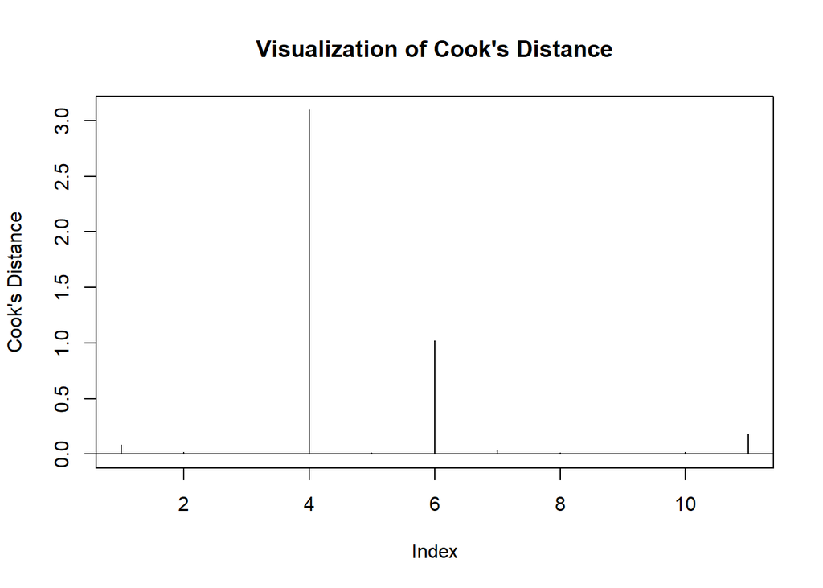

```r
plot(cd,type='h',ylab = "Cook's Distance",
     main = "Visualization of Cook's Distance")
abline(h=0)
```

All the above measures indicates theat the $4^{th}$ and $6^{th}$ obsn are influential observation

# Next step

so we remove the 6th and 4th obsn.

```r
df_ot<-df[-c(4,6),]

ssr1_updated<-lm(y_var~x_var,df_ot)
summary(ssr1_updated)
```

```
##
## Call:
## lm(formula = y_var ~ x_var, data = df_ot)
##
## Residuals:
##     Min      1Q  Median      3Q     Max
## -90.360 -26.351 -10.490  -1.119 160.746
##
## Coefficients:
##             Estimate Std. Error t value Pr(>|t|)
## (Intercept) -34.0013    94.9690  -0.358    0.731
## x_var         0.5380     0.2339   2.300    0.055 .
## ---
## Signif. codes:  0 '***' 0.001 '**' 0.01 '*' 0.05 '.' 0.1 ' ' 1
##
## Residual standard error: 73.5 on 7 degrees of freedom
## Multiple R-squared:  0.4304, Adjusted R-squared:  0.349
## F-statistic: 5.288 on 1 and 7 DF,  p-value: 0.05502
```

the parameters are insignificant and even the $R^2$ value is very low

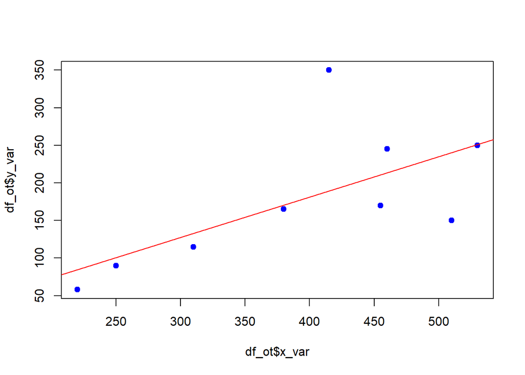

```r
plot(df_ot$x_var,df_ot$y_var,pch=19,col='blue')
abline(ssr1_updated,col='red')
```

The fit is again too bad, even the parameters are insignificant. So we don’t need to model the response variable with the regressor.

## Now we remove the 11 th obsn with high cooks distance

```r
df_ott<-df[-c(4,6,11),]
```

```r
ssr1_updated_2<-lm(y_var~x_var,df_ott)
summary(ssr1_updated_2)
```

```
##
## Call:
## lm(formula = y_var ~ x_var, data = df_ott)
##
## Residuals:
##     Min      1Q  Median      3Q     Max
## -65.203 -14.507   1.373  16.925  54.596
##
## Coefficients:
##             Estimate Std. Error t value Pr(>|t|)
## (Intercept) -37.7487    48.8416  -0.773  0.46894
## x_var         0.4960     0.1207   4.111  0.00628 **
## ---
## Signif. codes:  0 '***' 0.001 '**' 0.01 '*' 0.05 '.' 0.1 ' ' 1
##
## Residual standard error: 37.79 on 6 degrees of freedom
## Multiple R-squared:  0.738,  Adjusted R-squared:  0.6943
## F-statistic:  16.9 on 1 and 6 DF,  p-value: 0.00628
```

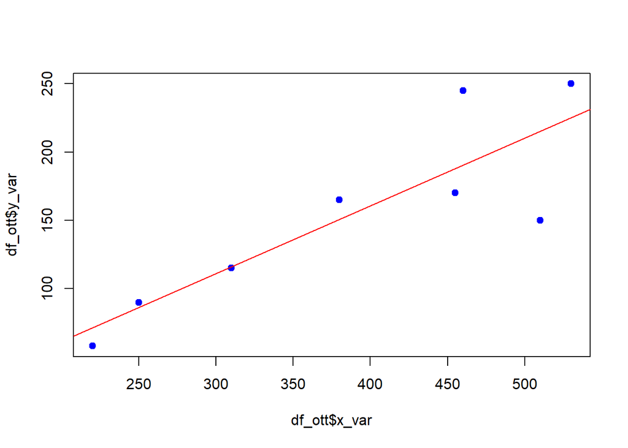

```r
plot(df_ott$x_var,df_ott$y_var,pch=19,col='blue')
abline(ssr1_updated_2,col='red')
```

So for the last model fits well , have higher $R^2$ values  
but the intercept is statistically insignificant. And so,

# Model without Intercept

```r
ssr1_updated_3<- lm(y_var~ 0 +x_var,df_ott)
summary(ssr1_updated_3)
```

```
##
## Call:
## lm(formula = y_var ~ 0 + x_var, data = df_ott)
##
## Residuals:
##    Min     1Q Median     3Q    Max
## -57.21 -18.99 -11.26  16.62  58.10
##
## Coefficients:
##       Estimate Std. Error t value Pr(>|t|)
## x_var  0.40629    0.03204   12.68 4.39e-06 ***
## ---
## Signif. codes:  0 '***' 0.001 '**' 0.01 '*' 0.05 '.' 0.1 ' ' 1
##
## Residual standard error: 36.69 on 7 degrees of freedom
## Multiple R-squared:  0.9583, Adjusted R-squared:  0.9523
## F-statistic: 160.8 on 1 and 7 DF,  p-value: 4.39e-06
```

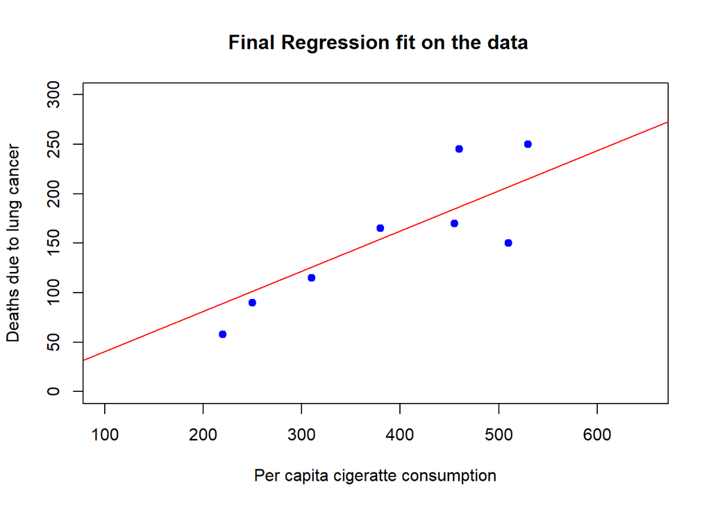

```r
plot(df_ott$x_var,df_ott$y_var,pch=19,col='blue',xlim = c(100,650),ylim = c(0,300),
     xlab = "Per capita cigeratte consumption",ylab = "Deaths due to lung cancer",
     main = " Final Regression fit on the data")
abline(ssr1_updated_3,col='red')
```

# The Model

$$lung\_cancer = (0.40629 )\times cigaratte\_consumption$$

# Problem2

### Data Input

```r
library(tidyverse)
library(readr)
library(readxl)
library(ggplot2)
library(dplyr)
```

```r
df2<- read.csv("C:\\Users\\souma\\Dropbox\\Mstat_CU\\Sem 2\\Regression_analysis_1\\Data Sets\\star_light_temp_dataset.csv")

colnames(df2)<-c("sl no","x_var","y_var")
head(df2)
```

|  | sl no | x_var | y_var |
| --- | --- | --- | --- |
| 1 | 1 | 4.37 | 5.23 |
| 2 | 2 | 4.56 | 5.74 |
| 3 | 3 | 4.26 | 4.93 |
| 4 | 4 | 4.56 | 5.74 |
| 5 | 5 | 4.30 | 5.19 |
| 6 | 6 | 4.46 | 5.46 |

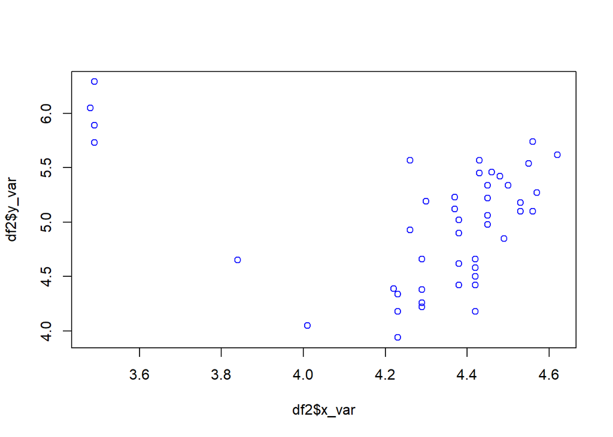

```r
plot(df2$x_var,df2$y_var,col="blue")
```

```r
ssr2<- lm(y_var~x_var,df2)
summary(ssr2)
```

```
##
## Call:
## lm(formula = y_var ~ x_var, data = df2)
##
## Residuals:
##     Min      1Q  Median      3Q     Max
## -1.1052 -0.5067  0.1327  0.4423  0.9390
##
## Coefficients:
##             Estimate Std. Error t value Pr(>|t|)
## (Intercept)   6.7935     1.2365   5.494 1.75e-06 ***
## x_var        -0.4133     0.2863  -1.444    0.156
## ---
## Signif. codes:  0 '***' 0.001 '**' 0.01 '*' 0.05 '.' 0.1 ' ' 1
##
## Residual standard error: 0.5646 on 45 degrees of freedom
## Multiple R-squared:  0.04427,    Adjusted R-squared:  0.02304
## F-statistic: 2.085 on 1 and 45 DF,  p-value: 0.1557
```

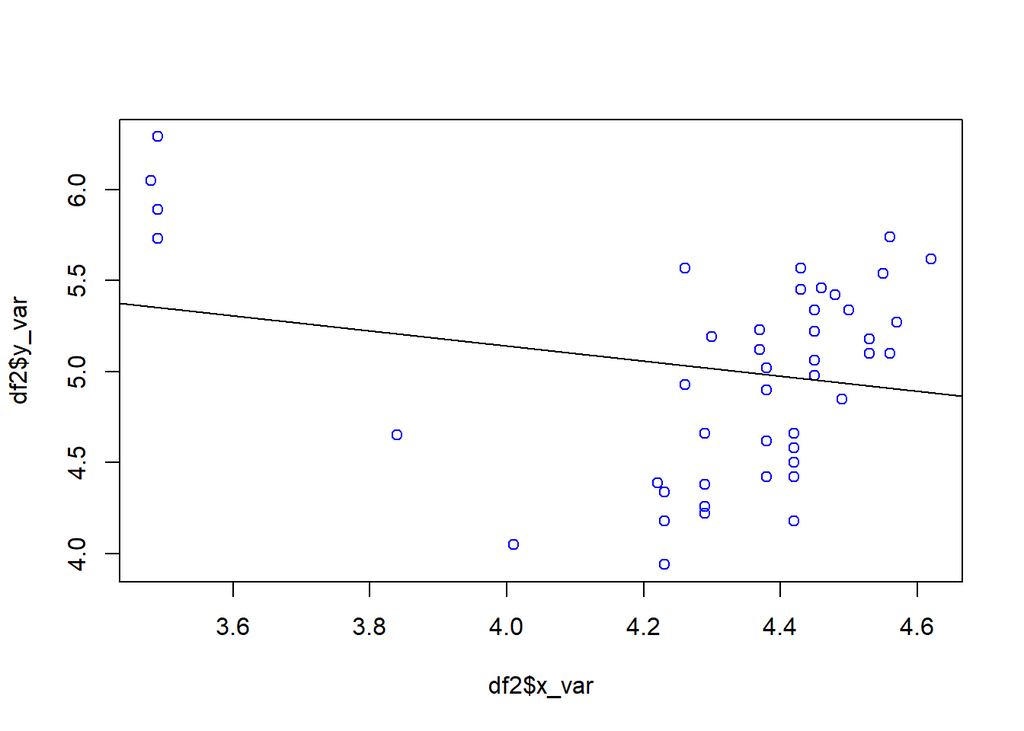

```r
plot(df2$x_var,df2$y_var,col='blue')
abline(ssr2)
```

```r
influence.measures(ssr2)
```

```
## Influence measures of
##   lm(formula = y_var ~ x_var, data = df2) :
##
##      dfb.1_ dfb.x_vr    dffit cov.r   cook.d    hat inf
## 1  -0.00899  0.01325  0.06490 1.061 2.14e-03 0.0222
## 2  -0.18113  0.19664  0.29979 0.981 4.37e-02 0.0373
## 3  -0.00645  0.00467 -0.02726 1.068 3.80e-04 0.0219
## 4  -0.18113  0.19664  0.29979 0.981 4.37e-02 0.0373
## 5   0.00460 -0.00158  0.04542 1.064 1.05e-03 0.0213
## 6  -0.06129  0.07045  0.15240 1.035 1.17e-02 0.0271
## 7  -0.26466  0.25483 -0.29879 1.082 4.46e-02 0.0781
## 8  -0.08146  0.08815  0.13148 1.067 8.75e-03 0.0387
## 9   0.03403 -0.02464  0.14390 1.026 1.04e-02 0.0219
## 10 -0.00491  0.00723  0.03543 1.067 6.41e-04 0.0222
## 11  0.35179 -0.34450  0.36509 1.266 6.73e-02 0.1941   *
```

[output cut: 36 more lines]

there are 4 influencial observation 11,20,30,34

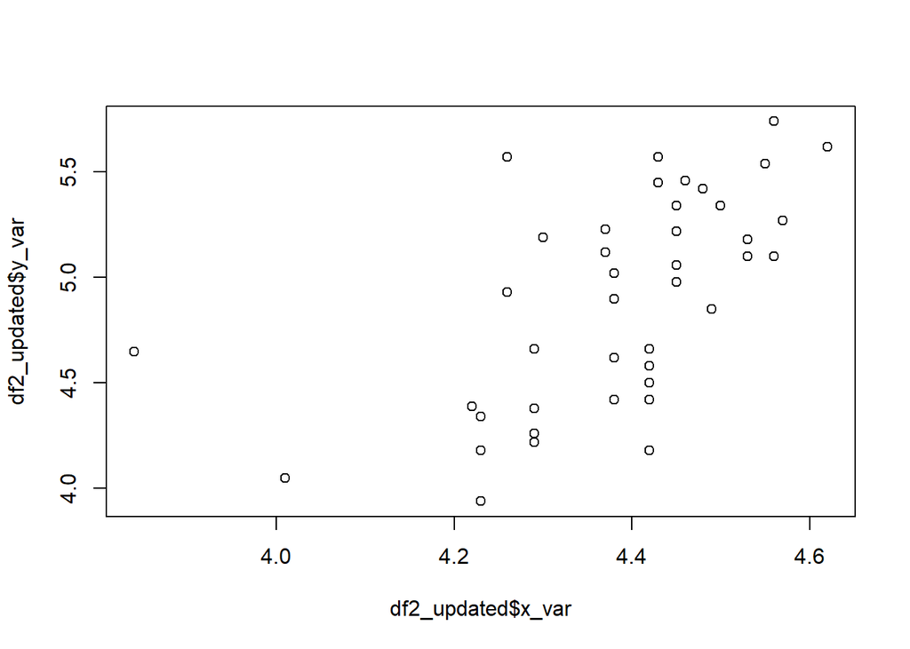

```r
df2_updated<-df2[-c(11,20,30,34),]

plot(df2_updated$x_var, df2_updated$y_var)
```

```r
ssr2_updated<- lm(y_var~x_var,df2_updated)
summary(ssr2_updated)
```

```
##
## Call:
## lm(formula = y_var ~ x_var, data = df2_updated)
##
## Residuals:
##     Min      1Q  Median      3Q     Max
## -0.8097 -0.3088 -0.0267  0.2866  0.9078
##
## Coefficients:
##             Estimate Std. Error t value Pr(>|t|)
## (Intercept)  -4.0565     1.8441  -2.200   0.0335 *
## x_var         2.0467     0.4202   4.871  1.7e-05 ***
## ---
## Signif. codes:  0 '***' 0.001 '**' 0.01 '*' 0.05 '.' 0.1 ' ' 1
##
## Residual standard error: 0.4058 on 41 degrees of freedom
## Multiple R-squared:  0.3666, Adjusted R-squared:  0.3511
## F-statistic: 23.73 on 1 and 41 DF,  p-value: 1.697e-05
```

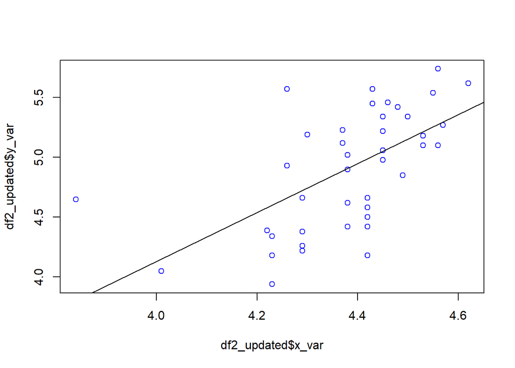

```r
plot(df2_updated$x_var,df2_updated$y_var,col="blue")
abline(ssr2_updated)
```

The $R^2$ is still too low

```r
influence.measures(ssr2_updated)
```

```
## Influence measures of
##   lm(formula = y_var ~ x_var, data = df2_updated) :
##
##       dfb.1_  dfb.x_vr    dffit cov.r   cook.d    hat inf
## 1   0.019135 -0.014733  0.13224 1.038 8.80e-03 0.0235
## 2  -0.212058  0.218403  0.28649 1.039 4.06e-02 0.0555
## 3   0.092908 -0.089463  0.13730 1.071 9.55e-03 0.0404
## 4  -0.212058  0.218403  0.28649 1.039 4.06e-02 0.0555
## 5   0.107682 -0.101916  0.20123 1.020 2.01e-02 0.0313
## 6  -0.069875  0.074959  0.16789 1.033 1.41e-02 0.0290
## 7   1.958271 -1.941804  2.01108 1.124 1.74e+00 0.3435   *
## 8   0.012766 -0.013127 -0.01683 1.117 1.45e-04 0.0594
## 9   0.335272 -0.322841  0.49547 0.834 1.10e-01 0.0404   *
## 10  0.012929 -0.009955  0.08935 1.058 4.06e-03 0.0235
## 12 -0.044465  0.050198  0.17727 1.015 1.56e-02 0.0253
```

[output cut: 32 more lines]

# Residual Plot

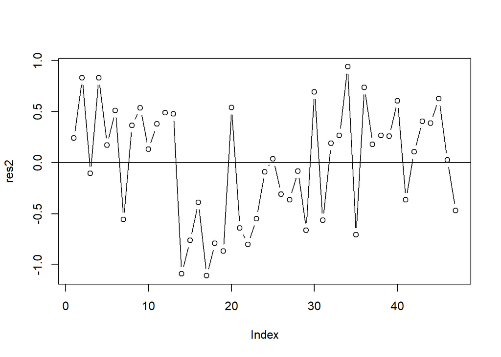

```r
res2<- residuals(ssr2)
plot(res2,type='b')
abline(h=0)
```

```r
#plot(density(res2))
```

# Standardize Residuals

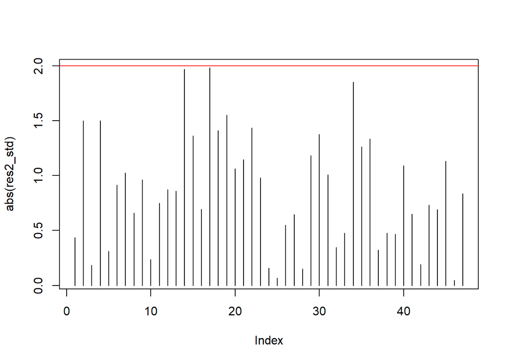

```r
res2_std <- rstandard(ssr2)

plot(abs(res2_std),type = 'h')
abline(h=2,col='red')
```

ordering in decreasing order

```r
res2_std[order(-abs(res2_std))]
```

```
##          17          14          34          19           4           2
## -1.98019464 -1.96777866  1.85243838 -1.55018182  1.50038693  1.50038693
##          22          18          30          15          36          35
## -1.43295112 -1.41054001  1.37442043 -1.36133881  1.33453895 -1.26350661
##          29          21          45          40          20           7
## -1.18159009 -1.14650188  1.13116891  1.08956114  1.06329630 -1.02625224
##          31          23           9           6          12          13
## -1.00889125 -0.98020444  0.96203147  0.91548130  0.87432813  0.85922888
##          47          11          43          16          44           8
## -0.83675925  0.74763947  0.73101644 -0.69331406  0.69233200  0.65990504
##          41          27          26          33          38          39
## -0.65061791 -0.64521571 -0.54986887  0.47695132  0.47695132  0.46627870
##           1          32          37           5          10          42
##  0.43463770  0.34512996  0.32214264  0.31103457  0.23762103  0.18977709
##           3          24          28          25          46
## -0.18408161 -0.15773325 -0.14903524  0.06592876  0.04618997
```

## Studentize Residual

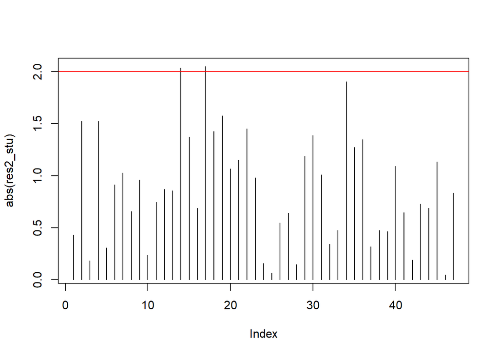

```r
res2_stu<- rstudent(ssr2)

plot(abs(res2_stu),type = 'h')
abline(h=2,col='red')
```

```r
res2_stu[order(-abs(res2_stu))]
```

```
##          17          14          34          19           4           2
## -2.04939273 -2.03532888  1.90584720 -1.57550504  1.52218503  1.52218503
##          22          18          30          15          36          35
## -1.45041761 -1.42667524  1.38851971 -1.37473341  1.34654294 -1.27215850
##          29          21          45          40          20           7
## -1.18694552 -1.15062098  1.13477943  1.09188565  1.06487784 -1.02687315
##          31          23           9           6          12          13
## -1.00909609 -0.97976810  0.96121811  0.91380172  0.87199716  0.85668474
##          47          11          43          16          44           8
## -0.83392273  0.74392041  0.72717900 -0.68925846  0.68827163  0.65571202
##          41          27          26          33          38          39
## -0.64639564 -0.64097816 -0.54556080  0.47281869  0.47281869  0.46218659
##           1          32          37           5          10          42
##  0.43068622  0.34172621  0.31891110  0.30789035  0.23511352  0.18773174
##           3          24          28          25          46
## -0.18209335 -0.15601395 -0.14740637  0.06519525  0.04567494
```

# Leverage

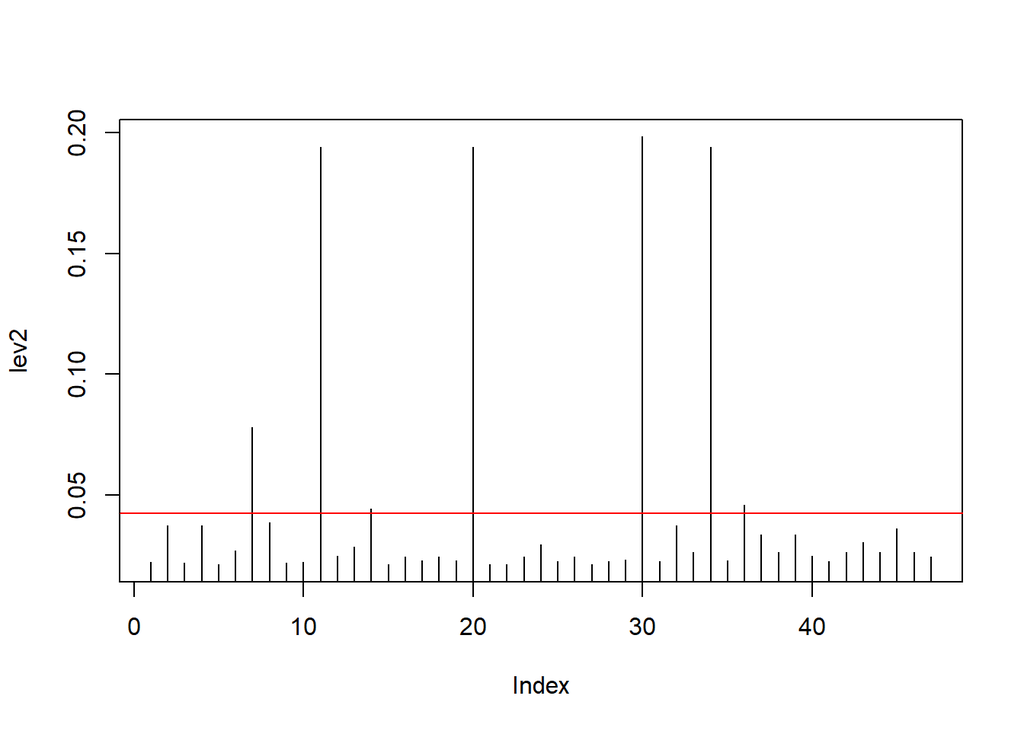

```r
lev2<- hatvalues(ssr2)

plot(lev2,type='h')
abline(h=2/47,col='red')
```

```r
which(lev2>(2/47))
```

```
##  7 11 14 20 30 34 36
##  7 11 14 20 30 34 36
```

# Dbeta

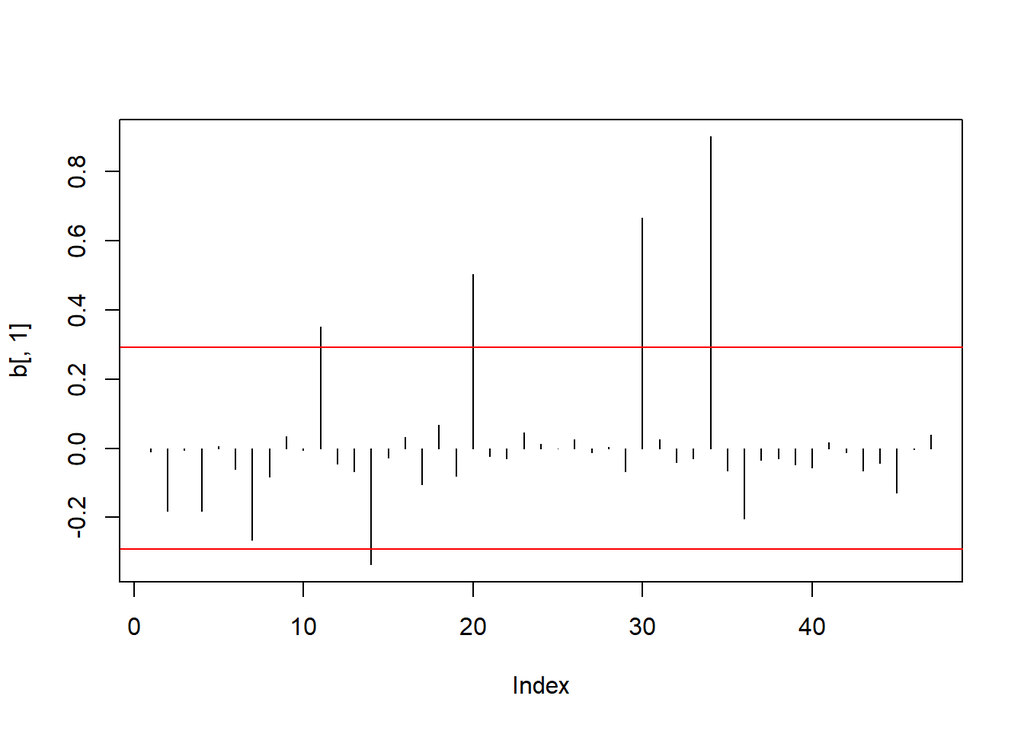

```r
b<- dfbetas(ssr2)

plot(b[,1],type='h')
abline(h=c((-2/sqrt(47)),(2/sqrt(47))) , col='red')
```

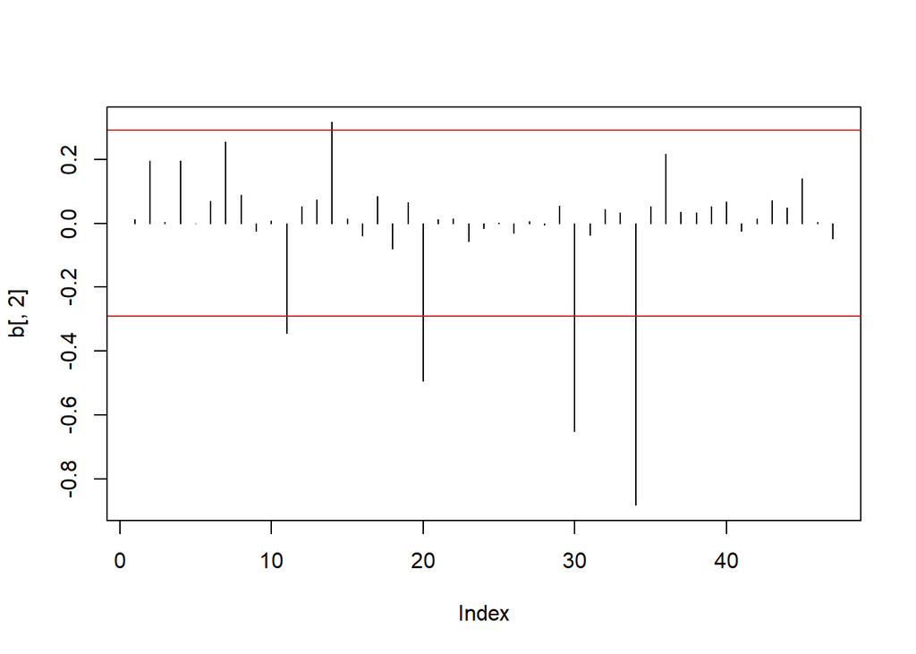

```r
plot(b[,2],type='h')
abline(h=c((-2/sqrt(47)),(2/sqrt(47))) , col='red')
```

# DFFITS

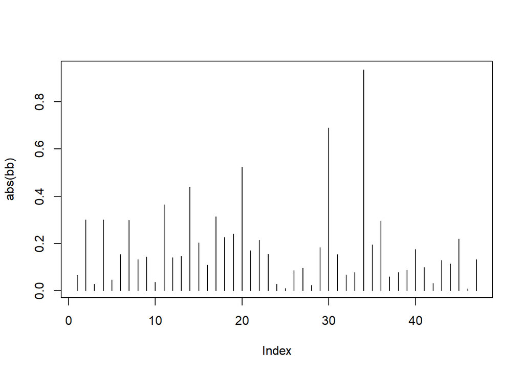

```r
bb<- dffits(ssr2)

plot(abs(bb),type='h')
```

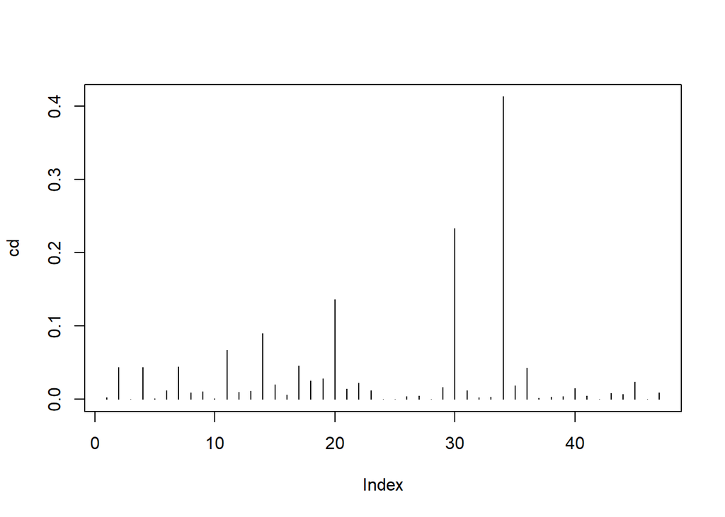

```r
cd<- cooks.distance(ssr2)

plot(cd,type='h')
```

```r
cd[order(-cd)]
```

```
##           34           30           20           14           11           17
## 4.132486e-01 2.336906e-01 1.361546e-01 8.997550e-02 6.731445e-02 4.599398e-02
##            7            4            2           36           19           18
## 4.458315e-02 4.366058e-02 4.366058e-02 4.291566e-02 2.818711e-02 2.486654e-02
##           45           22           15           35           29           40
## 2.394800e-02 2.242922e-02 2.024341e-02 1.872580e-02 1.669607e-02 1.520594e-02
##           21           23           31            6           13            9
## 1.435823e-02 1.200820e-02 1.173372e-02 1.165485e-02 1.090914e-02 1.037046e-02
##           12            8           47           43           44           16
## 9.791721e-03 8.754312e-03 8.750756e-03 8.421488e-03 6.476989e-03 6.007649e-03
##           41           27           39           26           33           38
## 4.879765e-03 4.547379e-03 3.793181e-03 3.778877e-03 3.073919e-03 3.073919e-03
##           32            1           37            5           10           42
## 2.310193e-03 2.144696e-03 1.810543e-03 1.052847e-03 6.410336e-04 4.866670e-04
##            3           24           28           25           46
## 3.796996e-04 3.795101e-04 2.560500e-04 5.010681e-05 2.882967e-05
```

# The more model

```r
df2_ott<- df2[-c(11,14,20,30,34),]


ssr3<- lm(y_var~x_var,df2_ott)
summary(ssr3)
```

```
##
## Call:
## lm(formula = y_var ~ x_var, data = df2_ott)
##
## Residuals:
##      Min       1Q   Median       3Q      Max
## -0.81089 -0.32092 -0.01575  0.28938  0.89870
##
## Coefficients:
##             Estimate Std. Error t value Pr(>|t|)
## (Intercept)  -3.8378     2.0339  -1.887 0.066451 .
## x_var         1.9974     0.4625   4.319 0.000101 ***
## ---
## Signif. codes:  0 '***' 0.001 '**' 0.01 '*' 0.05 '.' 0.1 ' ' 1
##
## Residual standard error: 0.4105 on 40 degrees of freedom
## Multiple R-squared:  0.318,  Adjusted R-squared:  0.3009
## F-statistic: 18.65 on 1 and 40 DF,  p-value: 0.0001006
```